# EJERCICIO_3_R

## Carga de datos

Comenzamos cargando las paqueterías y librerías necesarias, así como la base de datos que se utilizará en esta tercera parte del proyecto.

```r
# Instalamos las librerías necesarias para R.

#install.packages(c("dplyr", "ggplot2", "janitor", "inspectdf", "lubridate", "naniar", "readr", "reticulate",  "stringr", "tidyr", "visdat"))

library(dplyr)
library(ggplot2)
library(janitor)
library(inspectdf)
library(lubridate)
library(naniar)
library(readr)
library(reticulate)
library(stringr)
library(tidyr)
library(visdat)
```

```r
# Instalamos las libterías necesarias para Python.

py_install(c("pandas", "seaborn", "numpy", "matplotlib"))
```

```
Using virtual environment "C:/Users/23axe/Documents/.virtualenvs/r-reticulate" ...
```

```r
# Cargamos nuestra base de datos "coffe_ratings".

url <- "https://raw.githubusercontent.com/EduardoSelimMM/20260101_LecturaLimpiezaDatos/main/proyecto/coffee_ratings.csv"

datos <- read_csv(url)
```

## Actividad 0:

Realice un análisis de valores faltantes del objeto `datos`

Para ello empezaremos con el código en R.

```r
# Hacemos un análisis de los datos faltantes de nuestra base de datos.
miss_var_summary(datos)
```

```
# A tibble: 43 × 3
   variable             n_miss pct_miss
   <chr>                 <int>    <num>
 1 lot_number             1063     79.4
 2 farm_name               359     26.8
 3 mill                    315     23.5
 4 producer                231     17.3
 5 altitude_low_meters     230     17.2
 6 altitude_high_meters    230     17.2
 7 altitude_mean_meters    230     17.2
 8 altitude                226     16.9
 9 variety                 226     16.9
10 color                   218     16.3
# ℹ 33 more rows
```

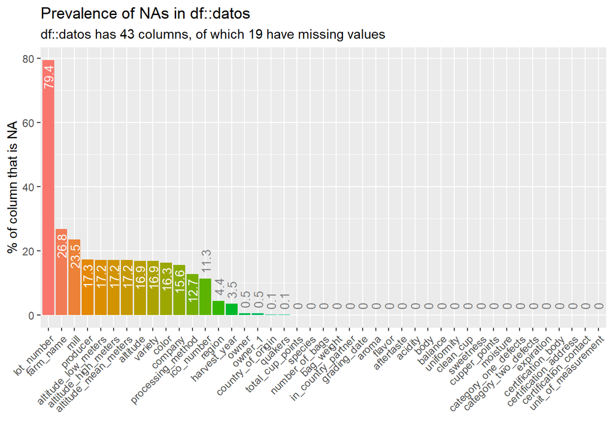

```r
# Hacemos una visualización de nuestros datos faltantes.
show_plot(inspect_na(datos))
```

Ahora se realiza el análisis de valores faltantes del objeto `datos` en Python.

```python
import pandas as pd
import seaborn as sns
import re
import numpy as np

sns.set(style="whitegrid")

url = "https://raw.githubusercontent.com/EduardoSelimMM/20260101_LecturaLimpiezaDatos/main/proyecto/coffee_ratings.csv"

datos = pd.read_csv(url)

faltantes = datos.isnull().sum().reset_index()
faltantes.columns = ["variable", "n_faltantes"]

# Porcentaje

faltantes["pct_faltantes"] = (faltantes["n_faltantes"] / len(datos)) * 100

# Filtrar solo los que tienen valores faltantes

faltantes = faltantes[faltantes["n_faltantes"] > 0]

# Ordenar

faltantes = faltantes.sort_values(by="n_faltantes", ascending=False)

faltantes
```

|  | variable | n_faltantes | pct_faltantes |
| --- | --- | --- | --- |
| 5 | lot_number | 1063 | 79.387603 |
| 4 | farm_name | 359 | 26.811053 |
| 6 | mill | 318 | 23.749066 |
| 33 | color | 270 | 20.164302 |
| 11 | producer | 232 | 17.326363 |
| 41 | altitude_high_meters | 230 | 17.176998 |
| 40 | altitude_low_meters | 230 | 17.176998 |
| 42 | altitude_mean_meters | 230 | 17.176998 |
| 9 | altitude | 226 | 16.878267 |
| 18 | variety | 226 | 16.878267 |
| 8 | company | 209 | 15.608663 |
| 19 | processing_method | 170 | 12.696042 |
| 7 | ico_number | 159 | 11.874533 |
| 10 | region | 59 | 4.406273 |
| 15 | harvest_year | 47 | 3.510082 |
| 17 | owner_1 | 7 | 0.522778 |
| 2 | owner | 7 | 0.522778 |
| 3 | country_of_origin | 1 | 0.074683 |
| 32 | quakers | 1 | 0.074683 |

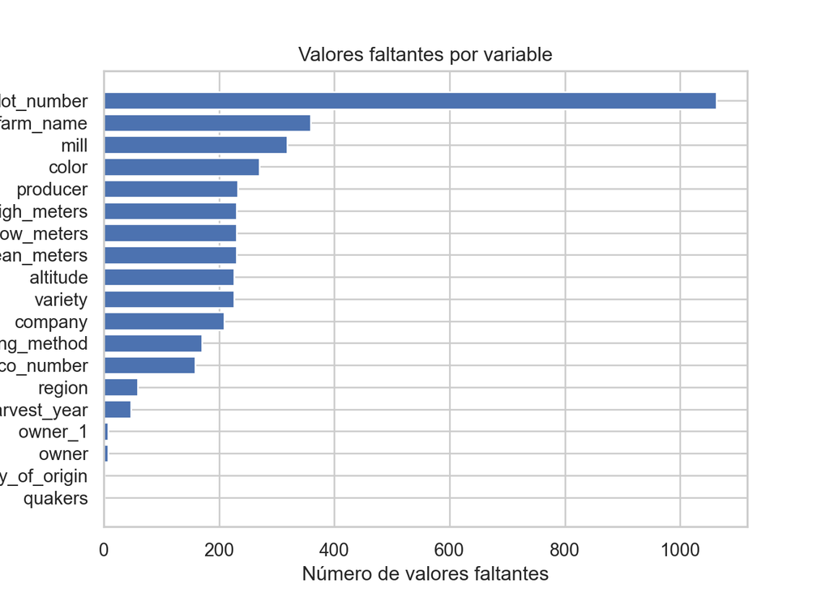

```python
import matplotlib.pyplot as plt

plt.figure()

# Asegurar orden descendente y luego invertir para barh

faltantes_plot = faltantes.sort_values(by="n_faltantes", ascending=False)

plt.barh(
    faltantes_plot["variable"][::-1],
    faltantes_plot["n_faltantes"][::-1]
)

plt.xlabel("Número de valores faltantes")
plt.ylabel("Variables")
plt.title("Valores faltantes por variable")

plt.show()
```

En ambos casos, podemos observar que, de las 43 variables presentes en la base de datos, 19 contienen valores faltantes (NA). Destaca la variable lot_number, que presenta un número considerablemente alto de valores ausentes (1063), lo que limita su utilidad para nuestro análisis. De igual forma, variables como farm_name y mill muestran niveles considerables de incompletitud.

Por otro lado, variables relacionadas con la altitud, presentan números similares de valores faltantes, lo que podría suponer la existencia de un patrón en la ausencia de datos.

## Actividad 1:

Crear una columna llamada `color2` que se base en los valores de la columna `color`, que asigne el valor NA si `color == NA`, “#00FF66” si `color == 'Green'`, “#CCEBC5” si `color == 'Bluish-green'` y “#BFFFFF” si `color == 'Blue-green'`

Comenzamos con la implementación en R.

Antes de empezar le daremos un breve vistazo a la columna *color* para identificar el formato de sus registros.

```r
# Datos únicos de la columna color.
unique(datos$color)
```

```
[1] "Green"        NA             "Bluish-Green" "None"         "Blue-Green"
```

Podemos observar que la columna contiene los valores “Green”, NA, “Bluish-Green”, “None” y “Blue-Green”; a partir de esta información, es posible construir la columna `color2`.

```r
# Empezamos haciendo un diccionario con cada una de las palabras clave y el color que le corresponde.
colores <- c(
  "green" = "#00FF66",
  "bluish-green" = "#CCEBC5",
  "blue-green" = "#BFFFFF"
)

# Hacemos una columna llamada color2 con base en los valores de la columna color y el diccionario que creamos.
datos <- datos |>
  mutate(
    color_limpio = str_to_lower(color),
    color2 = colores[color_limpio]
  )
# Mostramos los registros de la columna "color2"
datos |> select(color2)
```

```
# A tibble: 1,339 × 1
   color2
   <chr>
 1 #00FF66
 2 #00FF66
 3 <NA>
 4 #00FF66
 5 #00FF66
 6 #CCEBC5
 7 #CCEBC5
 8 <NA>
 9 <NA>
10 #00FF66
# ℹ 1,329 more rows
```

A continuación, se implementa el mismo procedimiento en Python.

Previo a ello, se realiza una revisión rápida de la columna `color` con el fin de identificar el formato de sus valores.

```python
# Ver valores únicos de la columna color

print(datos["color"].unique())
```

```
<StringArray>
['Green', nan, 'Bluish-Green', 'Blue-Green']
Length: 4, dtype: str
```

```python
# Crear diccionario de colores

colores = {
    "green": "#00FF66",
    "bluish-green": "#CCEBC5",
    "blue-green": "#BFFFFF"
}
```

```python
# Diccionario de colores

colores = {
    "green": "#00FF66",
    "bluish-green": "#CCEBC5",
    "blue-green": "#BFFFFF"
}

# Crear columna color2 basada en color

datos["color_limpio"] = datos["color"].str.lower()
datos["color2"] = datos["color_limpio"].map(colores)

# Mostrar solo las primeras 50 filas de color2

print(datos[["color2"]].head(50))
```

```
     color2
0   #00FF66
1   #00FF66
2       NaN
3   #00FF66
4   #00FF66
5   #CCEBC5
6   #CCEBC5
7       NaN
8       NaN
9   #00FF66
10      NaN
11      NaN
12      NaN
13      NaN
```

[output cut: 36 more lines]

En este caso solo mostramos los primeros 50 datos para no saturar de informacion, sin embargo en estos 50 datos podemos observar el cambio con su respectivo color.

Es importante destacar que tanto en R como en Python, todos los valores de color se convirtieron a minúsculas con el fin de estandarizar el formato y evitar inconsistencias al momento de asignar un color.

## Actividad 2:

Crear una columna llamada `bag_weight2` que se base en los valores de la columna `bag_weight`, que sólo contenga el valor numérico de ésta. Es decir, `bag_weight2` debe ser numérica. ¿Cuántas observaciones llevaron a ambigüedad para crear esta nueva columna?

Se comienza con la implementación en R.

Se empieza con un análisis exploratorio de la columna bag_weight, con el objetivo de identificar los valores que contiene.

```r
# Datos únicos de la columna bag_weight.
unique(datos$bag_weight)
```

```
 [1] "60 kg"    "1"        "30 kg"    "69 kg"    "1 kg"     "2 kg,lbs"
 [7] "6"        "3 lbs"    "50 kg"    "2 lbs"    "100 lbs"  "15 kg"
[13] "2 kg"     "2"        "70 kg"    "19200 kg" "5 lbs"    "1 kg,lbs"
[19] "6 kg"     "0 lbs"    "46 kg"    "40 kg"    "20 kg"    "34 kg"
[25] "1 lbs"    "660 kg"   "18975 kg" "12000 kg" "35 kg"    "66 kg"
[31] "80 kg"    "132 lbs"  "5 kg"     "25 kg"    "59 kg"    "18000 kg"
[37] "150 lbs"  "9000 kg"  "18 kg"    "10 kg"    "29 kg"    "1218 kg"
[43] "4 lbs"    "0 kg"     "13800 kg" "1500 kg"  "24 kg"    "80 lbs"
[49] "8 kg"     "3 kg"     "350 kg"   "67 kg"    "4 kg"     "55 lbs"
[55] "100 kg"   "130 lbs"
```

Se observa que algunos registros no cuentan con unidad de medida, presentan múltiples unidades, toman el valor de cero o contienen valores atípicos.

Por lo tanto, esta información se considerará en la construcción de la nueva columna `bag_weight2`. En particular, se realizará la conversión de libras a kilogramos con el fin de unificar las unidades de medida en la base de datos. Asimismo, aquellos registros que presenten más de una unidad de medida o que no cuenten con ninguna serán asignados como NA, ya que constituyen casos ambiguos que no pueden interpretarse con certeza y podrían generar inconsistencias en el análisis posterior.

```r
# Creamos las nuevas columnas.
datos <- datos |>
  mutate(
    # Extraemos número
    valor = as.numeric(str_extract(bag_weight, "\\d+")),

    # Detectamos la unidad de medida y convertimos lb a kg si es necesario
    bag_weight2 = case_when(
      str_detect(bag_weight, "kg") & !str_detect(bag_weight, "lbs") ~ valor,
      str_detect(bag_weight, "lbs") & !str_detect(bag_weight, "kg") ~ valor * 0.45359237,
      TRUE ~ NA_real_
    )
  ) |>
  select(-valor)

# Observamos los resultados obtenidos.
datos |>
  select(bag_weight, bag_weight2) |>
  head(10)
```

```
# A tibble: 10 × 2
   bag_weight bag_weight2
   <chr>            <dbl>
 1 60 kg               60
 2 60 kg               60
 3 1                   NA
 4 60 kg               60
 5 60 kg               60
 6 30 kg               30
 7 69 kg               69
 8 60 kg               60
 9 60 kg               60
10 60 kg               60
```

Podemos observar que la nueva columna extrae correctamente el valor numérico de la columna `bag_weight`.

Ahora nos preguntamos, ¿Cuántos observaciones llevaron a ambiguedad para crear esta nueva columna?

Para ello, consideraremos como valores atípicos aquellos registros que no cuentan con una unidad de medida, así como aquellos que presentan múltiples unidades.

```r
# Filtramos aquellos datos ambiguos.
ambiguedad <- datos |>
  filter(
    !is.na(bag_weight) &
    (
      str_detect(bag_weight, "^[0-9]+$") |   # sin unidad
      str_detect(bag_weight, ",")            # múltiples unidades
    )
  )

# Contamos el número de datos ambiguos.
nrow(ambiguedad)
```

```
[1] 29
```

A continuación, se replica el mismo ejercicio en Python.

Como primer paso, se realiza un análisis exploratorio de la columna `bag_weight` para identificar los tipos de valores que contiene.

```python
print(datos["bag_weight"].unique())
```

```
<StringArray>
[   '60 kg',        '1',    '30 kg',    '69 kg',     '1 kg', '2 kg,lbs',
        '6',    '3 lbs',    '50 kg',    '2 lbs',  '100 lbs',    '15 kg',
     '2 kg',        '2',    '70 kg', '19200 kg',    '5 lbs', '1 kg,lbs',
     '6 kg',    '0 lbs',    '46 kg',    '40 kg',    '20 kg',    '34 kg',
    '1 lbs',   '660 kg', '18975 kg', '12000 kg',    '35 kg',    '66 kg',
    '80 kg',  '132 lbs',     '5 kg',    '25 kg',    '59 kg', '18000 kg',
  '150 lbs',  '9000 kg',    '18 kg',    '10 kg',    '29 kg',  '1218 kg',
    '4 lbs',     '0 kg', '13800 kg',  '1500 kg',    '24 kg',   '80 lbs',
     '8 kg',     '3 kg',   '350 kg',    '67 kg',     '4 kg',   '55 lbs',
   '100 kg',  '130 lbs']
Length: 56, dtype: str
```

Se logra identificar que ciertos registros carecen de unidad de medida, incluyen más de una unidad, toman el valor cero o presentan valores atípicos.

En consecuencia, en la construcción de la columna `bag_weight2`, se convertirán las libras a kilogramos para unificar las unidades de medida. Asimismo, los registros con más de una unidad o sin unidad se asignarán como NA, ya que son ambiguos y podrían afectar el análisis.

```python
# Extraemos número
datos["valor"] = datos["bag_weight"].str.extract(r"(\d+)").astype(float)

# Creamos la nueva columna con condiciones
datos["bag_weight2"] = np.select(
    [
        datos["bag_weight"].str.contains("kg", na=False) & ~datos["bag_weight"].str.contains("lbs", na=False),
        datos["bag_weight"].str.contains("lbs", na=False) & ~datos["bag_weight"].str.contains("kg", na=False)
    ],
    [
        datos["valor"],
        datos["valor"] * 0.45359237
    ],
    default=np.nan
)


datos = datos.drop(columns=["valor"])

# Resultados
print(datos[["bag_weight", "bag_weight2"]].head(10))
```

```
  bag_weight  bag_weight2
0      60 kg         60.0
1      60 kg         60.0
2          1          NaN
3      60 kg         60.0
4      60 kg         60.0
5      30 kg         30.0
6      69 kg         69.0
7      60 kg         60.0
8      60 kg         60.0
9      60 kg         60.0
```

Se puede verificar que la nueva columna logra capturar adecuadamente el componente numérico de `bag_weight`.

A partir de esto, surge la pregunta: ¿cuántas observaciones generaron ambigüedad en la construcción de esta variable?

Para responderla, se considerarán como casos problemáticos aquellos registros que carecen de unidad de medida o que presentan más de una unidad.

```python
ambiguedad = datos[
    datos["bag_weight"].notna() & (
        datos["bag_weight"].str.match(r"^[0-9]+$") |   # sin unidad
        datos["bag_weight"].str.contains(",")          # múltiples unidades
    )
]

# Contamos el número de datos ambiguos.

print(len(ambiguedad))
```

```
29
```

Se observa que, tanto en R como en Python, se identificaron 29 observaciones que presentaran ambiguedad en la conversión de la variable `bag_weight` a formato numérico.

Es importante mencionar que se consideraron ambiguos aquellos registros que no especifican unidad de medida o que presentan más de una unidad en un mismo valor. Los valores atípicos o iguales a cero no se clasificaron como ambiguos, ya que corresponden a problemas de calidad del dato y no de formato.

## Actividad 3:

Crear dos columnas llamadas `method1` y `method2` que se basen en los valores de la columna `processing_method`, dividiendo en dos partes los valores dicha columna. ¿Cuántas observaciones llevaron a ambigüedad para crear esta nueva columna?

Se comienza con la implementación en R.

Realizaremos un análisis inicial de la columna processing_method con el objetivo de analizar su estructura antes de dividir sus valores.

```r
# Datos únicos de la columna processing_method.
unique(datos$processing_method)
```

```
[1] "Washed / Wet"              NA
[3] "Natural / Dry"             "Pulped natural / honey"
[5] "Semi-washed / Semi-pulped" "Other"
```

```r
# Dvidimos los valores de la columna processing_method en dos partes.
separacion <- str_split_fixed(
  datos$processing_method,
  " / ",
  n = 2
)

# Creamos las nuevas columnas.
datos <- datos |>
  mutate(
    method1 = separacion[, 1],
    method2 = separacion[, 2]
  )

# Vemos los resultados obtenidos.
datos |>
  select(processing_method, method1, method2) |>
  head(10)
```

```
# A tibble: 10 × 3
   processing_method method1 method2
   <chr>             <chr>   <chr>
 1 Washed / Wet      Washed  "Wet"
 2 Washed / Wet      Washed  "Wet"
 3 <NA>              <NA>    ""
 4 Natural / Dry     Natural "Dry"
 5 Washed / Wet      Washed  "Wet"
 6 Natural / Dry     Natural "Dry"
 7 Washed / Wet      Washed  "Wet"
 8 <NA>              <NA>    ""
 9 <NA>              <NA>    ""
10 Natural / Dry     Natural "Dry"
```

Comparamos las columnas `processing_method` , `method1` y `method2` con la finalidad de verificar que la separación se realizó correctamente.

Finalmente, nos preguntamos, ¿Cuántas observaciones llevaron a ambiguedad para crear esta nueva columna?

```r
# Filtramos y contamos aquellos datos que no tienen exactamente un " / ".
sum(
  !is.na(datos$processing_method) &
  str_count(datos$processing_method, " / ") != 1
)
```

```
[1] 26
```

A continuación, se desarrolla el mismo ejercicio en Python.

Como paso previo, se examina la columna `processing_method` para comprender su estructura antes de proceder a la separación de sus valores.

```python
print(datos["processing_method"].unique())
```

```
<StringArray>
[             'Washed / Wet',                         nan,
             'Natural / Dry',    'Pulped natural / honey',
 'Semi-washed / Semi-pulped',                     'Other']
Length: 6, dtype: str
```

```python
# Dividir en dos partes

separacion = datos["processing_method"].str.split(" / ", n=1, expand=True)

# Crear nuevas columnas

datos["method1"] = separacion[0]
datos["method2"] = separacion[1]

# Ver resultados

print(datos[["processing_method", "method1", "method2"]].head(10))
```

```
  processing_method  method1 method2
0      Washed / Wet   Washed     Wet
1      Washed / Wet   Washed     Wet
2               NaN      NaN     NaN
3     Natural / Dry  Natural     Dry
4      Washed / Wet   Washed     Wet
5     Natural / Dry  Natural     Dry
6      Washed / Wet   Washed     Wet
7               NaN      NaN     NaN
8               NaN      NaN     NaN
9     Natural / Dry  Natural     Dry
```

Se comparan las columnas `processing_method` , `method1` y `method2` con el fin de verificar que la separación se haya realizado correctamente.

Finalmente, se plantea la siguiente pregunta: ¿cuántas observaciones generaron ambigüedad al construir estas nuevas columnas?

```python
# Contar observaciones ambiguas

ambiguedad_count = (
    datos["processing_method"].notna() &
    (datos["processing_method"].str.count(" / ") != 1)
).sum()

print(ambiguedad_count)
```

```
26
```

Para esta actividad, tanto en R como en Python evaluamos la estructura de la variable `processing_method` mediante el conteo de ocurrencias del separador ” / “. Se identificaron 26 observaciones que no presentan exactamente dicho separador, lo que impide dividirlas de forma clara en dos. Esto indica que, aunque la mayoría de los registros siguen un formato consistente, existe un conjunto de datos con estructuras que pueden generar ambigüedad al construir las columnas `method1` y `method2`.

## Actividad 4:

Crear tres columnas llamadas `expiration_day`, `expiration_month` y `expiration_year` que se basen en los valores de la columna `expiration`. ¿Cuántas observaciones llevaron a ambigüedad para crear estas nuevas columnas?

Se comienza nuevamente con la implementación en R.

Como primer paso, se analiza la columna `expiration` con el fin de identificar la estructura de sus registros.

```r
# Datos únicos de la columna expiration.
head(unique(datos$expiration),20)
```

```
 [1] "April 3rd, 2016"      "May 31st, 2011"       "March 25th, 2016"
 [4] "September 3rd, 2014"  "September 17th, 2013" "September 2nd, 2011"
 [7] "March 29th, 2016"     "March 26th, 2016"     "March 12th, 2016"
[10] "August 31st, 2011"    "June 16th, 2011"      "April 7th, 2017"
[13] "March 24th, 2016"     "April 2nd, 2015"      "July 26th, 2013"
[16] "December 2nd, 2012"   "June 26th, 2015"      "May 18th, 2018"
[19] "May 18th, 2017"       "May 18th, 2011"
```

Podemos observar que los registros siguen el formato “mes día, año”, donde el día incluye sufijos como “st”, “nd”, “rd” o “th”. Por lo tanto, la separación puede realizarse de la siguiente manera.

```r
# Hacemos una limpieza previa de la columna expiration.
datos <- datos |>
  mutate(
    expiration_limpia = str_replace_all(expiration, "st|nd|rd|th", ""),
    expiration_limpia = str_replace_all(expiration_limpia, ",", "")
  )

fecha_expiration <- str_split_fixed(datos$expiration_limpia, " ", 3)

# Creamos las nuevas columnas.
datos <- datos |>
  mutate(
    expiration_month = fecha_expiration[, 1],
    expiration_day   = as.numeric(fecha_expiration[, 2]),
    expiration_year  = as.numeric(fecha_expiration[, 3])
  )

# Vemos los resultados obtenidos.
datos |>
  select(expiration, expiration_month, expiration_day, expiration_year) |>
  head(10)
```

```
# A tibble: 10 × 4
   expiration           expiration_month expiration_day expiration_year
   <chr>                <chr>                     <dbl>           <dbl>
 1 April 3rd, 2016      April                         3            2016
 2 April 3rd, 2016      April                         3            2016
 3 May 31st, 2011       May                          31            2011
 4 March 25th, 2016     March                        25            2016
 5 April 3rd, 2016      April                         3            2016
 6 September 3rd, 2014  September                     3            2014
 7 September 17th, 2013 September                    17            2013
 8 September 2nd, 2011  September                     2            2011
 9 September 2nd, 2011  September                     2            2011
10 March 29th, 2016     March                        29            2016
```

Al igual que en la actividad 3, comparamos las columnas `expiration`, `expiration_month`, `expiration_day` y `expiration_year` con la finalidad de verificar que la separación se realizó correctamente.

Ahora nos preguntamos, ¿Cuántas observaciones llevaron a ambigüedad para crear estas nuevas columnas?

```r
# Filtramos y contamos aquellos registros que no son NA y que no cumplen con el formato esperado.
sum(
  !is.na(datos$expiration) &
  !str_detect(datos$expiration, "^[A-Za-z]+ [0-9]{1,2}(st|nd|rd|th), [0-9]{4}$")
)
```

```
[1] 0
```

A continuación, se desarrolla el ejercicio en Python.

Como paso previo, se examina la columna `expiration` para comprender la estructura de sus registros.

```python
# Datos únicos de la columna expiration (primeros 20)

print(pd.Series(datos["expiration"].unique()).head(20))
```

```
0          April 3rd, 2016
1           May 31st, 2011
2         March 25th, 2016
3      September 3rd, 2014
4     September 17th, 2013
5      September 2nd, 2011
6         March 29th, 2016
7         March 26th, 2016
8         March 12th, 2016
9        August 31st, 2011
10         June 16th, 2011
11         April 7th, 2017
12        March 24th, 2016
13         April 2nd, 2015
14         July 26th, 2013
15      December 2nd, 2012
16         June 26th, 2015
17          May 18th, 2018
18          May 18th, 2017
19          May 18th, 2011
dtype: str
```

Se identifica que los registros presentan el formato “mes día, año”, en el que el día incorpora sufijos como “st”, “nd”, “rd” o “th”. Con base en esta estructura, es posible realizar la separación de la siguiente forma.

```python
# Limpieza de la columna expiration

datos["expiration_limpia"] = (
    datos["expiration"]
    .str.replace(r"st|nd|rd|th", "", regex=True)
    .str.replace(",", "", regex=False)
)

# Separar en partes

fecha_expiration = datos["expiration_limpia"].str.split(" ", n=2, expand=True)

# Crear nuevas columnas

datos["expiration_month"] = fecha_expiration[0]
datos["expiration_day"] = pd.to_numeric(fecha_expiration[1], errors="coerce")
datos["expiration_year"] = pd.to_numeric(fecha_expiration[2], errors="coerce")

# Ver resultados

print(datos[["expiration", "expiration_month", "expiration_day", "expiration_year"]].head(10))
```

```
             expiration expiration_month  expiration_day  expiration_year
0       April 3rd, 2016            April               3             2016
1       April 3rd, 2016            April               3             2016
2        May 31st, 2011              May              31             2011
3      March 25th, 2016            March              25             2016
4       April 3rd, 2016            April               3             2016
5   September 3rd, 2014        September               3             2014
6  September 17th, 2013        September              17             2013
7   September 2nd, 2011        September               2             2011
8   September 2nd, 2011        September               2             2011
9      March 29th, 2016            March              29             2016
```

De manera similar a la actividad 3, se contrastan las columnas `expiration`, `expiration_month`, `expiration_day` y `expiration_year` para comprobar que la separación se haya realizado correctamente.

A partir de ello, surge la siguiente pregunta: ¿cuántas observaciones generaron ambigüedad al construir estas nuevas columnas?

```python
# Contar observaciones ambiguas

ambiguedad_count = (
    datos["expiration"].notna() &
    ~datos["expiration"].str.match(r"^[A-Za-z]+ [0-9]{1,2}(st|nd|rd|th), [0-9]{4}$", na=False)
).sum()

print(ambiguedad_count)
```

```
0
```

## Actividad 5:

Crear dos columnas llamadas `harvest_mes` y `harvest_anio` que se basen en los valores de la columna `harvest_year`, dividiendo en dos partes los valores dicha columna. ¿Cuántas observaciones llevaron a ambigüedad para crear esta nueva columna?

Se inicia el ejercicio en R.

Empezamos analizando los registros que contiene la columna `harvest_year` con el objetivo de identificar su formato y así evitar errores al momento de dividirla en dos partes.

```r
# Datos únicos de la columna harvest_year.
unique(datos$harvest_year)
```

```
 [1] "2014"                     NA
 [3] "2013"                     "2012"
 [5] "March 2010"               "Sept 2009 - April 2010"
 [7] "May-August"               "2009/2010"
 [9] "2015"                     "2011"
[11] "2016"                     "2015/2016"
[13] "2010"                     "Fall 2009"
[15] "2017"                     "2009 / 2010"
[17] "2010-2011"                "2009-2010"
[19] "2009 - 2010"              "2013/2014"
[21] "2017 / 2018"              "mmm"
[23] "TEST"                     "December 2009-March 2010"
[25] "2014/2015"                "2011/2012"
[27] "January 2011"             "4T/10"
[29] "2016 / 2017"              "23 July 2010"
[31] "January Through April"    "1T/2011"
[33] "4t/2010"                  "4T/2010"
[35] "August to December"       "Mayo a Julio"
[37] "47/2010"                  "Abril - Julio"
[39] "4t/2011"                  "Abril - Julio /2011"
[41] "Spring 2011 in Colombia." "3T/2011"
[43] "2016/2017"                "1t/2011"
[45] "2018"                     "4T72010"
[47] "08/09 crop"
```

Se identificó una amplia diversidad de formatos en la variable `harvest_year`, incluyendo registros con año simple, combinaciones de mes y año, rangos de años, intervalos con meses, descripciones textuales y formatos no estándar.

Así que para hacer la separación se considerarán con “formato correcto” aquellos registros que permiten identificar de manera explícita un año en formato de cuatro dígitos y, en su caso, un mes asociado. Esto incluye registros con formato “mes año”, únicamente año o rangos de años claramente definidos. Por el contrario, se consideran “ambiguos” aquellos registros que no contienen un año identificable o presentan formatos no estandarizados que impiden una separación directa.

```r
# Creamos las nuevas columnas.
datos <- datos |>
  mutate(
    harvest_mes = str_extract(
      harvest_year,
      regex("January|February|March|April|May|June|July|August|September|October|November|December|Jan|Feb|Mar|Apr|Jun|Jul|Aug|Sept|Sep|Oct|Nov|Dec|Mayo|Abril", ignore_case = TRUE)
    ),
    harvest_anio = str_extract(harvest_year, "\\d{4}")
  )

# Vemos los resultados obtenidos.
datos |>
  select(harvest_year, harvest_mes, harvest_anio) |>
  head(200)
```

```
# A tibble: 200 × 3
   harvest_year harvest_mes harvest_anio
   <chr>        <chr>       <chr>
 1 2014         <NA>        2014
 2 2014         <NA>        2014
 3 <NA>         <NA>        <NA>
 4 2014         <NA>        2014
 5 2014         <NA>        2014
 6 2013         <NA>        2013
 7 2012         <NA>        2012
 8 March 2010   March       2010
 9 March 2010   March       2010
10 2014         <NA>        2014
# ℹ 190 more rows
```

Podemos observar que, debido a la falta de una estructura homogénea en los datos, se generan múltiples valores *NA* en las columnas `harvest_mes` y `harvest_anio`.

Por lo que nos preguntamos, ¿Cuántas observaciones llevaron a ambigüedad para crear esta nueva columna?

```r
# Filtramos y contamos aquellos registros que no son NA y que no cumplen con el formato esperado.
sum(
  !is.na(datos$harvest_year) &
  str_count(datos$harvest_year, " ") != 1
)
```

```
[1] 1284
```

A continuación, se desarrolla el ejercicio en Python.

Como paso inicial, se examinan los registros de la columna `harvest_year` para identificar su formato y prevenir posibles errores al dividirla en dos componentes.

```python
# Datos únicos de la columna harvest_year

print(datos["harvest_year"].unique())
```

```
<StringArray>
[                    '2014',                        nan,
                     '2013',                     '2012',
               'March 2010',   'Sept 2009 - April 2010',
               'May-August',                '2009/2010',
                     '2015',                     '2011',
                     '2016',                '2015/2016',
                     '2010',                'Fall 2009',
                     '2017',              '2009 / 2010',
                '2010-2011',                '2009-2010',
              '2009 - 2010',                '2013/2014',
              '2017 / 2018',                      'mmm',
                     'TEST', 'December 2009-March 2010',
                '2014/2015',                '2011/2012',
             'January 2011',                    '4T/10',
              '2016 / 2017',             '23 July 2010',
    'January Through April',                  '1T/2011',
                  '4t/2010',                  '4T/2010',
       'August to December',             'Mayo a Julio',
                  '47/2010',            'Abril - Julio',
                  '4t/2011',      'Abril - Julio /2011',
 'Spring 2011 in Colombia.',                  '3T/2011',
                '2016/2017',                  '1t/2011',
                     '2018',                  '4T72010',
               '08/09 crop']
Length: 47, dtype: str
```

Se observó una gran variedad de formatos en la variable `harvest_year`, incluyendo registros con un solo año, combinaciones de mes y año, rangos de años, intervalos con meses, descripciones textuales y otros formatos no estandarizados.

Para realizar la separación, se considerarán como “formato válido” aquellos registros en los que sea posible identificar claramente un año en formato de cuatro dígitos y, en su caso, un mes asociado. Esto abarca casos como “mes-año”, únicamente año o rangos de años bien definidos. En cambio, se clasificarán como “ambiguos” aquellos registros que no contienen un año identificable o presentan estructuras no estandarizadas que dificultan una separación directa.

```python
# Crear nuevas columnas

datos["harvest_mes"] = datos["harvest_year"].str.extract(
    r"(January|February|March|April|May|June|July|August|September|October|November|December|Jan|Feb|Mar|Apr|Jun|Jul|Aug|Sept|Sep|Oct|Nov|Dec|Mayo|Abril)",
    flags=re.IGNORECASE
)

datos["harvest_anio"] = datos["harvest_year"].str.extract(r"(\d{4})")

# Ver resultados

print(datos[["harvest_year", "harvest_mes", "harvest_anio"]].head(50))
```

```
              harvest_year harvest_mes harvest_anio
0                     2014         NaN         2014
1                     2014         NaN         2014
2                      NaN         NaN          NaN
3                     2014         NaN         2014
4                     2014         NaN         2014
5                     2013         NaN         2013
6                     2012         NaN         2012
7               March 2010       March         2010
8               March 2010       March         2010
9                     2014         NaN         2014
10                    2014         NaN         2014
11                    2014         NaN         2014
12                    2014         NaN         2014
13  Sept 2009 - April 2010        Sept         2009
```

[output cut: 36 more lines]

Se aprecia que la ausencia de una estructura uniforme en los datos da lugar a la aparición de múltiples valores NA en las columnas `harvest_mes` y `harvest_anio`.

Ante esto, surge la siguiente pregunta: ¿cuántas observaciones generaron ambigüedad al construir estas nuevas columnas?

```python
# Contar observaciones ambiguas

ambiguedad_count = (
    datos["harvest_year"].notna() &
    (datos["harvest_year"].str.count(" ") != 1)
).sum()

print(ambiguedad_count)
```

```
1284
```

## Actividad 6:

Elabore una visualización con {ggplot2} que identifique alguna relación entre las columnas total_cup_points, acidity y color2 de tal forma que se puedan identificar los colores de la variable `color2`. Es decir, debemos ver los colores, “#00FF66”, “#CCEBC5” y “#BFFFFF”.

Se comienza el ejercicio con la implementación en R.

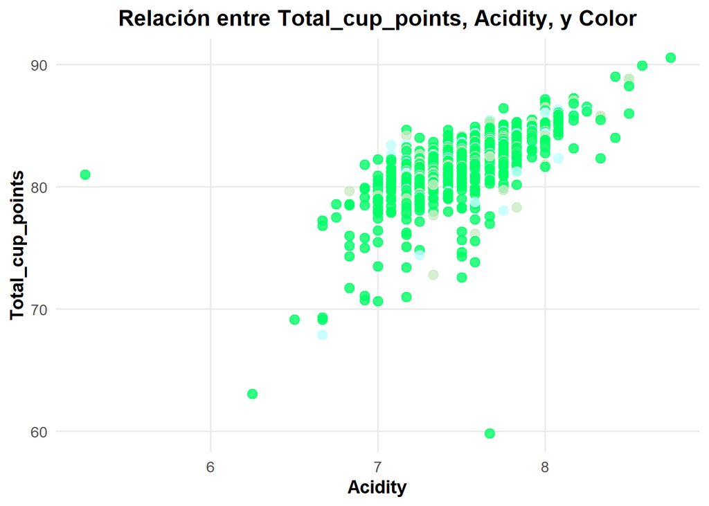

```r
# Empezamos filtrando los datos necesarios para nuestra gráfica.
ggplot(
  datos |>
    filter(
      !is.na(acidity),
      !is.na(total_cup_points),
      !is.na(color2),
      !(acidity == 0 & total_cup_points == 0)  # Eliminamos observaciones atípicas.
    ),

  # Definimos las variables para los ejes: x = acidity, y = total_cup_points.
  aes(x = acidity, y = total_cup_points)
) +

  # Agregamos los puntos.
  geom_point(
    aes(color = color2),
    size = 3,
    alpha = 0.8
  ) +

  # Usamos directamente los valores de color2 como colores.
  scale_color_identity() +

  # Agregamos los títulos y etiquetas necesarias a la gráfica.
  labs(
    title = "Relación entre Total_cup_points, Acidity, y Color",
    x = "Acidity",
    y = "Total_cup_points"
  ) +

  # Aplicamos un tema minimalista.
  theme_minimal(base_size = 13) +

  # Modificamos detalles de visualización de la gráfica para que sea entendible.
  theme(
    plot.title = element_text(face = "bold", hjust = 0.5),
    plot.subtitle = element_text(hjust = 0.5),
    axis.title = element_text(face = "bold"),
    panel.grid.minor = element_blank()
  )
```

A continuación, se reproduce la misma visualización en Python.

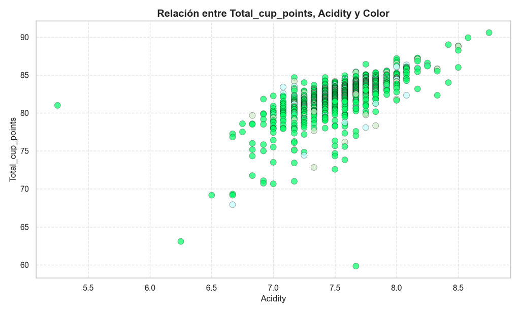

```python
# Filtrar datos

df_plot = datos[
    datos["acidity"].notna() &
    datos["total_cup_points"].notna() &
    datos["color2"].notna() &
    ~((datos["acidity"] == 0) & (datos["total_cup_points"] == 0))
]

# Gráfica mejorada

plt.figure(figsize=(10,6))

plt.scatter(
    df_plot["acidity"],
    df_plot["total_cup_points"],
    c=df_plot["color2"],
    s=70,
    alpha=0.7,
    edgecolors="black",
    linewidths=0.3
)

plt.title("Relación entre Total_cup_points, Acidity y Color", fontsize=14, weight="bold")
plt.xlabel("Acidity", fontsize=12)
plt.ylabel("Total_cup_points", fontsize=12)

plt.grid(True, linestyle="--", alpha=0.5)

plt.tight_layout()
plt.show()
```

Es importante notar que, en ambos casos, se decidió eliminar aquellos valores atípicos que podían afectar la visualización de la gráfica, con el fin de hacerla más clara y fácil de entender para el espectador.

Las gráficas muestran una relación positiva entre `acidity` y `total_cup_points`, ya que a mayor acidez, mayor tiende a ser el puntaje del café. Esto es consistente en la mayoría de las observaciones, lo que indica que la acidez es un atributo importante en la evaluación de calidad.

En cuanto a `color2`, se distinguen los colores “#00FF66”, “#CCEBC5” y “#BFFFFF”, aunque predomina claramente el primero.

## Actividad 7:

Elabore una visualización de densidad con {ggplot2} de la variable `bag_weight2` diferenciando a los valores de `species`.

Se inicia el ejercicio con la implementación en R.

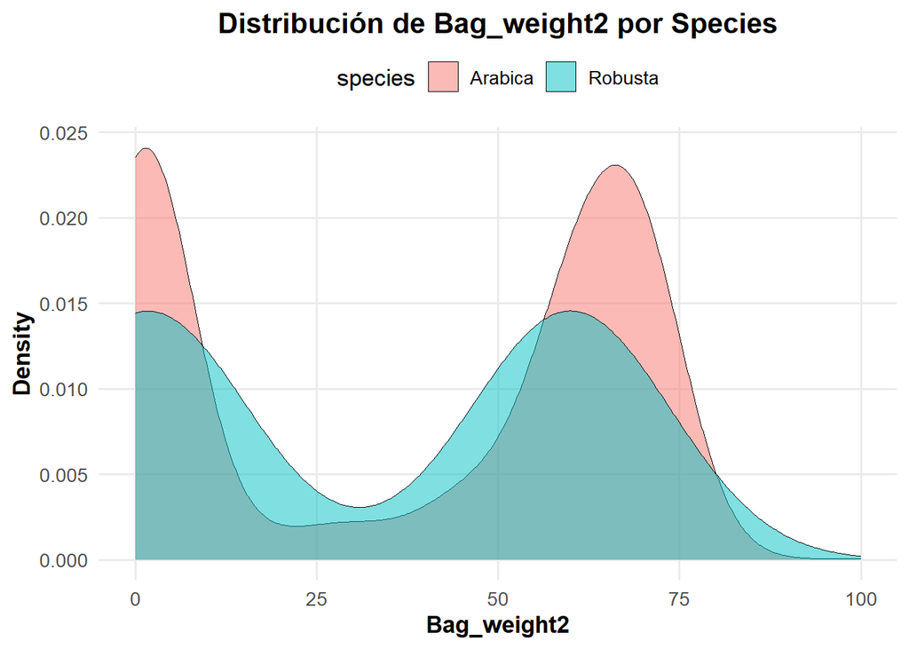

```r
ggplot(
  datos |>
    filter(
      !is.na(bag_weight2), # Eliminamos los valores faltantes.
      bag_weight2 < 300
    ),
  aes(x = bag_weight2, fill = species)
) +

  geom_density(
    alpha = 0.5,
    color = "black",
    size = 0.3
  ) +

  labs(
    title = "Distribución de Bag_weight2 por Species",
    x = "Bag_weight2",
    y = "Density",
    fill = "species"
  ) +

  coord_cartesian(
    xlim = range(
      datos$bag_weight2[
        !is.na(datos$bag_weight2) & datos$bag_weight2 < 300
      ]
    )
  ) +

  theme_minimal(base_size = 13) +

  theme(
    plot.title = element_text(face = "bold", hjust = 0.5),
    axis.title = element_text(face = "bold"),
    legend.position = "top",
    panel.grid.minor = element_blank()
  )
```

A continuación, se presenta la visualización correspondiente en Python.

```python
# Filtrar datos
df_plot = datos[
    datos["bag_weight2"].notna() &
    (datos["bag_weight2"] < 300)
]

# Calcular límites dinámicos
xmin = df_plot["bag_weight2"].min()
xmax = df_plot["bag_weight2"].max()

# Gráfica de densidad por especie
plt.figure(figsize=(10,6))

for especie in df_plot["species"].dropna().unique():
    subset = df_plot[df_plot["species"] == especie]
    sns.kdeplot(
        subset["bag_weight2"],
        fill=True,
        alpha=0.4,
        linewidth=1,
        label=especie
    )

# Ajustar eje x dinámicamente
plt.xlim(xmin, xmax)
```

```
(0.0, 100.0)
```

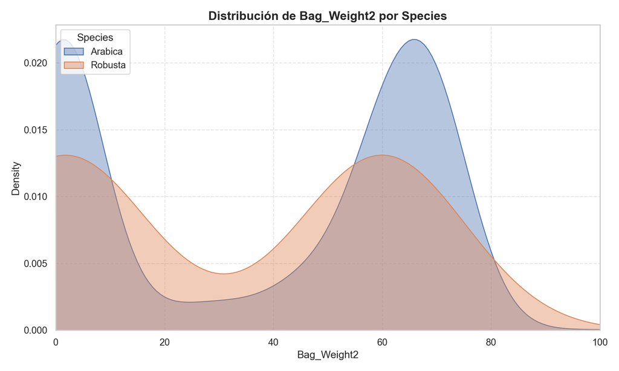

```python
plt.title("Distribución de Bag_Weight2 por Species", fontsize=14, weight="bold")
plt.xlabel("Bag_Weight2", fontsize=12)
plt.ylabel("Density", fontsize=12)

plt.legend(title="Species", loc="upper left", bbox_to_anchor=(0, 1))
plt.grid(True, linestyle="--", alpha=0.5)

plt.tight_layout()
plt.show()
```

Es importante destacar que, tanto en R como en Python, se optó por eliminar los valores atípicos (aquellos registros con valores faltantes (NA) y aquellos cuyo valor numérico supera 300), ya que podían distorsionar la visualización. Esta decisión se tomó con el objetivo de obtener una gráfica más clara y fácil de interpretar.

En la “vida real”, esto indica que el peso de las bolsas no es un criterio confiable para diferenciar entre Arabica y Robusta, ya que ambas se comercializan en rangos similares y el tamaño del empaque depende más de decisiones de mercado que del tipo de café.

## Actividad 8:

Elabore una visualización que relacione el año/mes de expiración con el `total_cup_points` sólo de los granos mexicanos, brasileños, colombianos y guatemaltecos.

Se comienza el ejercicio con la implementación en R.

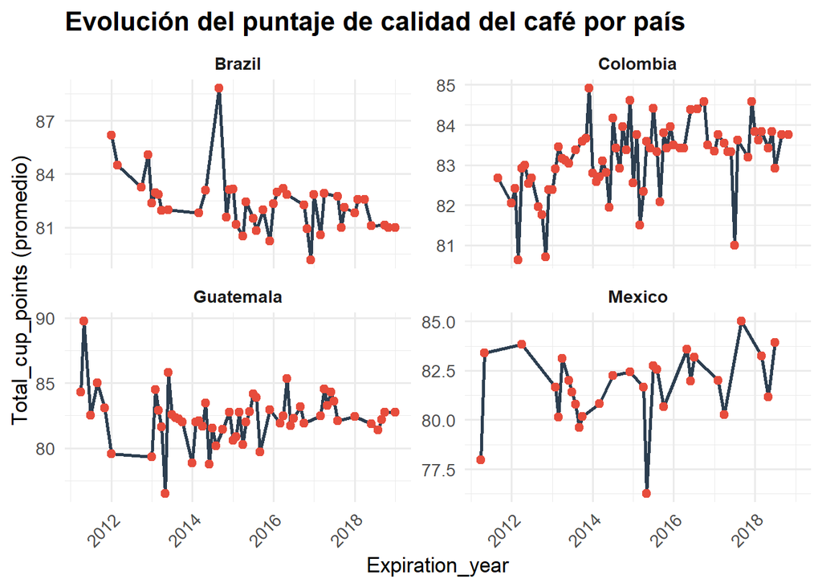

```r
# Empezamos ordenando los meses para que aparezcan en orden cronológico.
datos_plot <- datos |>
  filter(
    country_of_origin %in% c("Mexico", "Brazil", "Colombia", "Guatemala"),
    !is.na(expiration_year),
    !is.na(expiration_month),
    !is.na(total_cup_points)
  ) |>
  mutate(

    # Convertimos la fecha tipo "YYYY-MM".
    fecha = ymd(paste(expiration_year, expiration_month, "01", sep = "-"))
  ) |>
  group_by(country_of_origin, fecha) |>
  summarise(
    total_cup_points = mean(total_cup_points, na.rm = TRUE),
    .groups = "drop"
  )

# Generamos la gráfica a partir de los datos previamente modificados.
ggplot(datos_plot, aes(x = fecha, y = total_cup_points)) +
  geom_line(size = 1, color = "#2C3E50") +
  geom_point(size = 2, color = "#E74C3C") +
  facet_wrap(~country_of_origin, scales = "free_y") +
  labs(
    title = "Evolución del puntaje de calidad del café por país",
    x = "Expiration_year",
    y = "Total_cup_points (promedio)"
  ) +

  # Aplicamos un tema minimalista.
  theme_minimal(base_size = 13) +


  # Modificamos detalles de visualización de la gráfica para que sea entendible.
  theme(
    strip.text = element_text(face = "bold"),
    plot.title = element_text(face = "bold", size = 16),
    plot.subtitle = element_text(size = 12),
    axis.text.x = element_text(angle = 45, hjust = 1)
  )
```

A continuación, se muestra la visualización correspondiente en Python.

```python
# Filtrar datos

df_plot = datos[
    datos["country_of_origin"].isin(["Mexico", "Brazil", "Colombia", "Guatemala"]) &
    datos["expiration_year"].notna() &
    datos["expiration_month"].notna() &
    datos["total_cup_points"].notna()
].copy()


df_plot["fecha"] = pd.to_datetime(
    df_plot["expiration_year"].astype(str) + "-" +
    df_plot["expiration_month"] + "-01",
    errors="coerce"
)

# Agrupar y promediar

df_plot = (
    df_plot
    .groupby(["country_of_origin", "fecha"], as_index=False)["total_cup_points"]
    .mean()
)


countries = df_plot["country_of_origin"].unique()

fig, axes = plt.subplots(len(countries), 1, figsize=(10, 8), sharex=True)

if len(countries) == 1:
    axes = [axes]

for ax, country in zip(axes, countries):
    subset = df_plot[df_plot["country_of_origin"] == country]

    ax.plot(subset["fecha"], subset["total_cup_points"], linewidth=1.5)
    ax.scatter(subset["fecha"], subset["total_cup_points"], s=30)

    ax.set_title(country, fontsize=11, weight="bold")
    ax.grid(True, linestyle="--", alpha=0.5)


fig.suptitle("Evolución del puntaje de calidad del café por país", fontsize=14, weight="bold")
axes[-1].set_xlabel("Expiration_year", fontsize=11)

for ax in axes:
    ax.set_ylabel("Total_cup_points", fontsize=10)

plt.xticks(rotation=45)
```

```
(array([14610., 14975., 15340., 15706., 16071., 16436., 16801., 17167.,
       17532., 17897.]), [Text(14610.0, 0, '2010'), Text(14975.0, 0, '2011'), Text(15340.0, 0, '2012'), Text(15706.0, 0, '2013'), Text(16071.0, 0, '2014'), Text(16436.0, 0, '2015'), Text(16801.0, 0, '2016'), Text(17167.0, 0, '2017'), Text(17532.0, 0, '2018'), Text(17897.0, 0, '2019')])
```

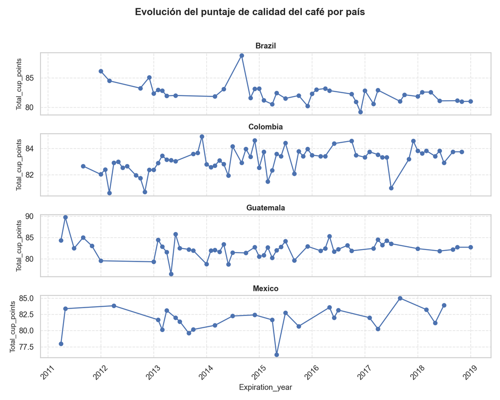

```python
plt.tight_layout(rect=[0, 0, 1, 0.96])
plt.show()
```

Tanto en R como en Python, la gráfica indica que no existe una relación clara entre el año/mes de expiración y el puntaje del café, ya que los valores se mantienen relativamente estables en el tiempo.

En cambio, las diferencias más relevantes se observan entre países: Colombia presenta puntajes altos y consistentes, México muestra mayor variabilidad, mientras que Guatemala y Brasil se mantienen en niveles intermedios. En conjunto, esto sugiere que la calidad del café depende más de factores propios de cada país que del tiempo.

## Actividad 9:

Elabore una visualización con {ggplot2} que relacione el mes de expiración con el `altitude_mean_meters`, `altitude_low_meters` y `altitude_high_meters` sólo de los granos mexicanos, brasileños, colombianos y guatemaltecos de los años de expiración 2016 y 2017.

Empecemos desarrollando el ejercicio en R.

Antes de comenzar a graficar, haremos un análisis del número de registros disponibles con el fin de evaluar la calidad de los datos y su distribución en las variables de interés, para verificar si existe suficiente información por mes de expiración para construir una visualización representativa.

```r
# Creamos una tabla para hacer una visualización de los datos.
datos_diag_tabla <- datos |>
  mutate(

    # Crear variables de mes incluyendo los NA como categoría.
    expiration_month2 = ifelse(
      is.na(expiration_month),
      "NA",
      as.character(expiration_month)
    )
  ) |>

  # Filtramos los países y años de interés para está actividad.
  filter(
    (country_of_origin == "Mexico" |
     country_of_origin == "Brazil" |
     country_of_origin == "Colombia" |
     country_of_origin == "Guatemala") &
    (expiration_year == 2016 | expiration_year == 2017)
  ) |>

  # Agrupamos por país, año y mes.
  group_by(country_of_origin, expiration_year, expiration_month2) |>

  # Contamos los registros totales y disponibilidad de altitudes
  summarise(
    total_registros = n(),
    con_altitude_mean = sum(!is.na(altitude_mean_meters)),
    con_altitude_low  = sum(!is.na(altitude_low_meters)),
    con_altitude_high = sum(!is.na(altitude_high_meters)),
    .groups = "drop"
  ) |>

  # Ordenamos para una mejor lectura.
  arrange(country_of_origin, expiration_year, expiration_month2)

datos_diag_tabla
```

```
# A tibble: 48 × 7
   country_of_origin expiration_year expiration_month2 total_registros
   <chr>                       <dbl> <chr>                       <int>
 1 Brazil                       2016 April                           3
 2 Brazil                       2016 December                        3
 3 Brazil                       2016 February                        1
 4 Brazil                       2016 January                         4
 5 Brazil                       2016 May                             1
 6 Brazil                       2016 November                        2
 7 Brazil                       2016 October                        14
 8 Brazil                       2017 April                           2
 9 Brazil                       2017 Augu                            9
10 Brazil                       2017 January                         2
# ℹ 38 more rows
# ℹ 3 more variables: con_altitude_mean <int>, con_altitude_low <int>,
#   con_altitude_high <int>
```

Aunque las variables de altitud cuentan con mayor disponibilidad de datos, la falta de coincidencia con el mes reduce significativamente el número de observaciones completas, lo que impide un análisis concluyente de su relación.

Por ello, el análisis se realiza de forma exploratoria, utilizando únicamente las observaciones con información completa y representando las altitudes mediante promedios mensuales, dada la escasez de datos por mes.

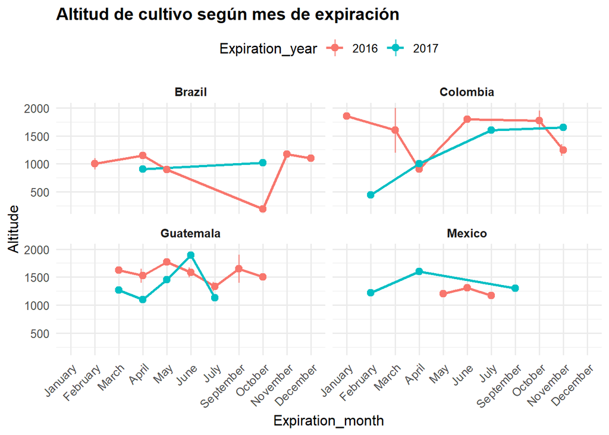

```r
# Empezamos ordenando los meses para que aparezcan en orden cronológico.
datos <- datos |>
  mutate(
    expiration_month = factor(
      expiration_month,
      levels = c(
        "January", "February", "March", "April", "May", "June",
        "July", "August", "September", "October", "November", "December"
      )
    )
  )

# Filtramos los datos necesarios para nuestro gráfico.
datos_filtrados <- datos |>
  filter(
    (country_of_origin == "Mexico" |
     country_of_origin == "Brazil" |
     country_of_origin == "Colombia" |
     country_of_origin == "Guatemala") &
    (expiration_year == 2016 | expiration_year == 2017) &
    !is.na(expiration_month) &
    !is.na(altitude_mean_meters) &
    !is.na(altitude_low_meters) &
    !is.na(altitude_high_meters)
  )

# Resumimos por país, año y mes.
datos_resumen <- datos_filtrados |>
  group_by(country_of_origin, expiration_year, expiration_month) |>
  summarise(
    altitude_mean_meters = mean(altitude_mean_meters, na.rm = TRUE),
    altitude_low_meters  = mean(altitude_low_meters, na.rm = TRUE),
    altitude_high_meters = mean(altitude_high_meters, na.rm = TRUE),
    .groups = "drop"
  )

# Generamos la gráfica a partir de los datos previamente modificados.
ggplot(
  datos_resumen,
  aes(
    x = expiration_month,
    y = altitude_mean_meters,
    color = factor(expiration_year),
    group = expiration_year
  )
) +

  # Hacemos un rango de altitud a partir del valor de la variable altitude_low_meters y altitude_high_meters.
  geom_linerange(
    aes(
      ymin = altitude_low_meters,
      ymax = altitude_high_meters
    ),
    linewidth = 0.7,
    alpha = 0.7,
    position = position_dodge(width = 0.3)
  ) +

  # Hacemos una línea de tendencia.
  geom_line(linewidth = 1) +

  # Agregamos los puntos de la altitud media.
  geom_point(size = 2.5) +

  # Hacemos una gráfica por país.
  facet_wrap(~ country_of_origin, ncol = 2, scales = "fixed") +
  labs(
    title = "Altitud de cultivo según mes de expiración",
    x = "Expiration_month",
    y = "Altitude",
    color = "Expiration_year"
  ) +

  # Aplicamos un tema minimalista.
  theme_minimal(base_size = 12) +

  # Modificamos detalles de visualización de la gráfica para que sea entendible.
  theme(
    plot.title = element_text(face = "bold", size = 14),
    plot.subtitle = element_text(size = 11),
    axis.text.x = element_text(angle = 45, hjust = 1),
    strip.text = element_text(face = "bold"),
    legend.position = "top"
  )
```

A continuación, se realiza el ejercicio en Python.

Como paso previo a la visualización, se analiza la cantidad de registros disponibles para evaluar la calidad de los datos y su distribución en las variables de interés. De esta forma, se verifica si hay información suficiente por mes de expiración para construir una gráfica representativa.

```python
# Copia de la base
datos_diag_tabla = datos.copy()

# Crear variable incluyendo NA como categoría
datos_diag_tabla["expiration_month2"] = (
    datos_diag_tabla["expiration_month"]
    .fillna("NA")
    .astype(str)
)

# Países de interés
paises = ["Mexico", "Brazil", "Colombia", "Guatemala"]

# Filtrar años y países
datos_diag_tabla = datos_diag_tabla[
    (datos_diag_tabla["country_of_origin"].isin(paises)) &
    (datos_diag_tabla["expiration_year"].isin([2016, 2017]))
]

# Tabla diagnóstica
datos_diag_tabla = (
    datos_diag_tabla
    .groupby(
        ["country_of_origin",
         "expiration_year",
         "expiration_month2"],
        dropna=False
    )
    .agg(
        total_registros=("expiration_month2", "size"),
        con_altitude_mean=(
            "altitude_mean_meters",
            lambda x: x.notna().sum()
        ),
        con_altitude_low=(
            "altitude_low_meters",
            lambda x: x.notna().sum()
        ),
        con_altitude_high=(
            "altitude_high_meters",
            lambda x: x.notna().sum()
        )
    )
    .reset_index()
    .sort_values(
        ["country_of_origin",
         "expiration_year",
         "expiration_month2"]
    )
)

datos_diag_tabla
```

|  | country_of_origin | expiration_year | expiration_month2 | total_registros | con_altitude_mean | con_altitude_low | con_altitude_high |
| --- | --- | --- | --- | --- | --- | --- | --- |
| 0 | Brazil | 2016 | April | 3 | 1 | 1 | 1 |
| 1 | Brazil | 2016 | December | 3 | 1 | 1 | 1 |
| 2 | Brazil | 2016 | February | 1 | 1 | 1 | 1 |
| 3 | Brazil | 2016 | January | 4 | 0 | 0 | 0 |
| 4 | Brazil | 2016 | May | 1 | 1 | 1 | 1 |
| 5 | Brazil | 2016 | November | 2 | 2 | 2 | 2 |
| 6 | Brazil | 2016 | October | 14 | 13 | 13 | 13 |
| 7 | Brazil | 2017 | April | 2 | 2 | 2 | 2 |
| 8 | Brazil | 2017 | Augu | 9 | 9 | 9 | 9 |
| 9 | Brazil | 2017 | January | 2 | 0 | 0 | 0 |
| 10 | Brazil | 2017 | March | 1 | 0 | 0 | 0 |
| 11 | Brazil | 2017 | October | 2 | 1 | 1 | 1 |
| 12 | Brazil | 2017 | September | 1 | 0 | 0 | 0 |
| 13 | Colombia | 2016 | April | 6 | 5 | 5 | 5 |
| 14 | Colombia | 2016 | Augu | 3 | 2 | 2 | 2 |
| 15 | Colombia | 2016 | January | 1 | 1 | 1 | 1 |
| 16 | Colombia | 2016 | June | 2 | 2 | 2 | 2 |
| 17 | Colombia | 2016 | March | 3 | 1 | 1 | 1 |
| 18 | Colombia | 2016 | November | 6 | 5 | 5 | 5 |
| 19 | Colombia | 2016 | October | 2 | 2 | 2 | 2 |
| 20 | Colombia | 2017 | April | 2 | 1 | 1 | 1 |
| 21 | Colombia | 2017 | Augu | 3 | 2 | 2 | 2 |
| 22 | Colombia | 2017 | December | 1 | 0 | 0 | 0 |
| 23 | Colombia | 2017 | February | 3 | 2 | 2 | 2 |
| 24 | Colombia | 2017 | January | 3 | 0 | 0 | 0 |
| 25 | Colombia | 2017 | July | 1 | 1 | 1 | 1 |
| 26 | Colombia | 2017 | June | 1 | 0 | 0 | 0 |
| 27 | Colombia | 2017 | May | 1 | 0 | 0 | 0 |
| 28 | Colombia | 2017 | November | 3 | 1 | 1 | 1 |
| 29 | Guatemala | 2016 | April | 2 | 2 | 2 | 2 |
| 30 | Guatemala | 2016 | July | 3 | 3 | 3 | 3 |
| 31 | Guatemala | 2016 | June | 4 | 4 | 4 | 4 |
| 32 | Guatemala | 2016 | March | 3 | 3 | 3 | 3 |
| 33 | Guatemala | 2016 | May | 1 | 1 | 1 | 1 |
| 34 | Guatemala | 2016 | October | 2 | 2 | 2 | 2 |
| 35 | Guatemala | 2016 | September | 1 | 1 | 1 | 1 |
| 36 | Guatemala | 2017 | April | 3 | 1 | 1 | 1 |
| 37 | Guatemala | 2017 | Augu | 4 | 4 | 4 | 4 |
| 38 | Guatemala | 2017 | July | 1 | 1 | 1 | 1 |
| 39 | Guatemala | 2017 | June | 4 | 4 | 4 | 4 |
| 40 | Guatemala | 2017 | March | 3 | 3 | 3 | 3 |
| 41 | Guatemala | 2017 | May | 5 | 4 | 4 | 4 |
| 42 | Mexico | 2016 | July | 3 | 3 | 3 | 3 |
| 43 | Mexico | 2016 | June | 3 | 3 | 3 | 3 |
| 44 | Mexico | 2016 | May | 1 | 1 | 1 | 1 |
| 45 | Mexico | 2017 | April | 1 | 1 | 1 | 1 |
| 46 | Mexico | 2017 | February | 2 | 2 | 2 | 2 |
| 47 | Mexico | 2017 | September | 1 | 1 | 1 | 1 |

Aunque las variables de altitud cuentan con más datos, la falta de coincidencia con el mes reduce las observaciones completas, lo que limita el análisis. Por ello, se realiza un enfoque exploratorio utilizando únicamente datos completos y promedios mensuales.

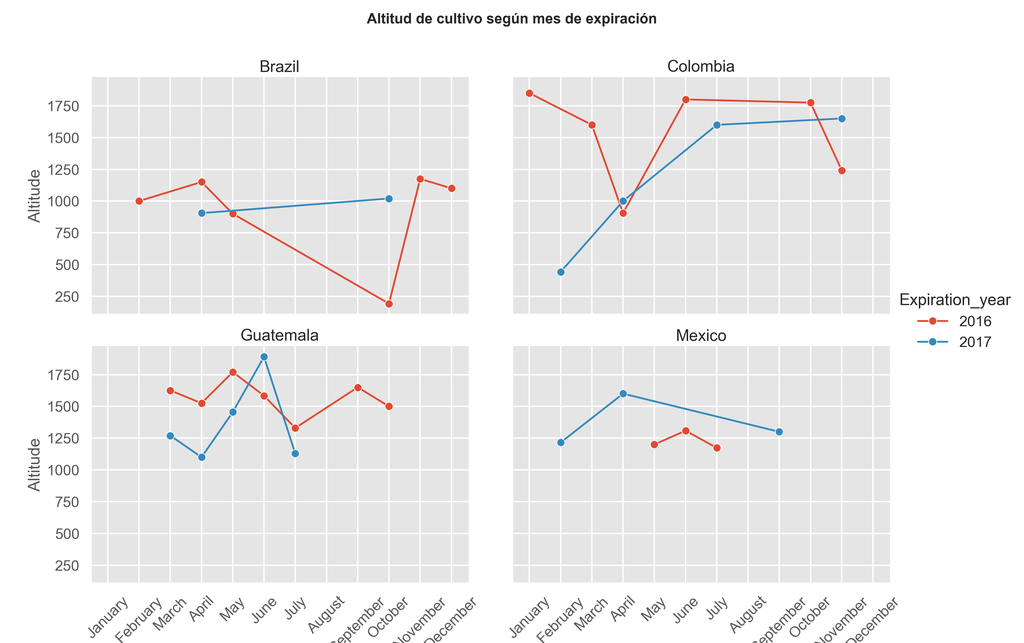

```python
plt.close("all")

# Orden cronológico de meses
orden_meses = [
    "January","February","March","April",
    "May","June","July","August",
    "September","October","November","December"
]

datos["expiration_month"] = pd.Categorical(
    datos["expiration_month"],
    categories=orden_meses,
    ordered=True
)

# Filtrar observaciones completas
datos_filtrados = datos[
    (datos["country_of_origin"].isin(paises)) &
    (datos["expiration_year"].isin([2016, 2017])) &
    (datos["expiration_month"].notna()) &
    (datos["altitude_mean_meters"].notna()) &
    (datos["altitude_low_meters"].notna()) &
    (datos["altitude_high_meters"].notna())
]

# Promedios mensuales
datos_resumen = (
    datos_filtrados
    .groupby(
        ["country_of_origin", "expiration_year", "expiration_month"],
        observed=True
    )
    .agg({
        "altitude_mean_meters": "mean",
        "altitude_low_meters": "mean",
        "altitude_high_meters": "mean"
    })
    .reset_index()
)

plt.style.use("ggplot")
sns.set_context("talk")

g = sns.FacetGrid(
    datos_resumen,
    col="country_of_origin",
    col_wrap=2,
    hue="expiration_year",
    height=5,
    aspect=1.4,
    sharey=True
)

g.map(
    sns.lineplot,
    "expiration_month",
    "altitude_mean_meters",
    marker="o",
    linewidth=2
);

g.add_legend(title="Expiration_year");
g.set_axis_labels("Expiration_month", "Altitude");
g.set_titles("{col_name}");

# Rotar meses
for ax in g.axes.flatten():
    ax.tick_params(axis="x", rotation=45)

plt.subplots_adjust(top=0.88)

g.fig.suptitle(
    "Altitud de cultivo según mes de expiración",
    fontsize=16,
    fontweight="bold"
);

plt.show()
```

```python
plt.close(g.fig)
```

En general, no se observa un patrón mensual uniforme entre países, ya que la altitud varía según el origen del grano y el año de expiración. En el caso de Colombia, se aprecia una tendencia más clara en algunos meses; en contraste, México muestra un comportamiento más estable, mientras que Brasil y Guatemala presentan mayor variabilidad. Asimismo, la amplitud del rango de altitud cambia entre meses, lo que indica diferencias en la dispersión de los datos.

## Actividad 10:

Elabore una visualización con {ggplot2} que relacione el `aftertaste`, `acidity`, `body` y `species` en un mismo canvas.

Se comienza el ejercicio con la implementación en R.

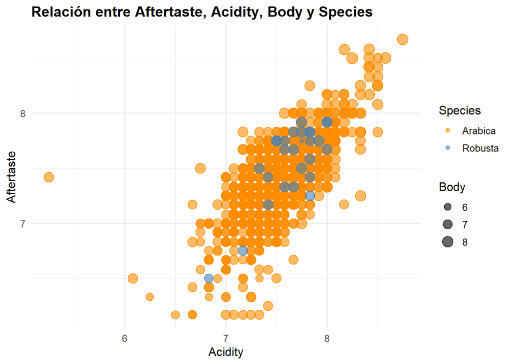

```r
# Empezamos filtrando los datos necesarios para nuestra gráfica.
ggplot(
  datos |>
    filter(
      aftertaste > 0,   # Eliminamos registros con valores no válidos o atípicos.
      acidity > 0
    ),
  aes(
    x = acidity,
    y = aftertaste,
    color = species,
    size = body
  )
) +

  # Agrega los puntos (scatter plot).
  geom_point(alpha = 0.6) +

  # Definimos los colores para cada especie.
  scale_color_manual(values = c("darkorange", "steelblue")) +

  # Ajustamos el rango de tamaños de los puntos de la gráfica.
  scale_size(range = c(1, 5)) +

  # Agregamos los títulos y etiquetas necesarias a la gráfica
  labs(
    title = "Relación entre Aftertaste, Acidity, Body y Species",
    x = "Acidity",
    y = "Aftertaste",
    color = "Species",
    size = "Body"
  ) +

  # Aplica un tema minimalista.
  theme_minimal(base_size = 12) +

  # Modificamos detalles de visualización de la gráfica para que sea entendible.
  theme(
    plot.title = element_text(face = "bold"),
    legend.position = "right"
  )
```

A continuación, se presenta la gráfica correspondiente en Python.

```python
# Filtrar observaciones válidas

datos_filtrados = datos[
    (datos["aftertaste"] > 0) &
    (datos["acidity"] > 0)
].copy()

# Verificar especies

print(datos_filtrados["species"].value_counts())
```

```
species
Arabica    1310
Robusta      28
Name: count, dtype: int64
```

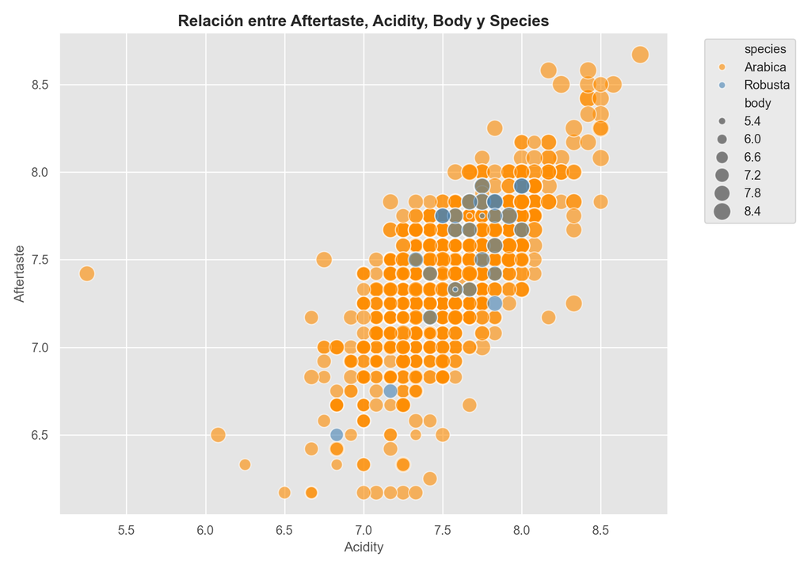

```python
plt.style.use("ggplot")
sns.set_context("notebook")

plt.figure(figsize=(10,7))

sns.scatterplot(
    data=datos_filtrados,
    x="acidity",
    y="aftertaste",
    hue="species",
    size="body",
    palette=["darkorange","steelblue"],
    sizes=(20,250),   # similar a scale_size(range=c(1,5))
    alpha=0.6
)

plt.title(
    "Relación entre Aftertaste, Acidity, Body y Species",
    fontsize=14,
    fontweight="bold"
)

plt.xlabel("Acidity")
plt.ylabel("Aftertaste")

plt.legend(
    bbox_to_anchor=(1.05,1),
    loc="upper left"
)

plt.tight_layout()
plt.show()
```

Es importante destacar que, tanto en R como en Python, se decidió eliminar los valores atípicos que podían afectar Dla visualización de la gráfica, con el fin de hacerla más clara y fácil de interpretar para el espectador.

Podemos observar que las gráficas muestra una relación positiva entre `acidity` y`aftertaste`, es decir, a mayor acidez, mayor es el retrogusto.

Por otro lado, en cuanto a la especie, *Arabica* domina y presenta mayor dispersión, mientras que *Robusta* se concentra en un rango más acotado. Además, los valores más altos de `body` tienden a ubicarse donde `acidity` y`aftertaste` son elevados, lo que sugiere que un mayor cuerpo está asociado a una mayor intensidad.